# Introduction

The general theme of today is to answer a simple question, is my hypothesis correct?

Today we will focus on an easily simulated problem, the biased coin.

Now we can set up a function which will "flip a coin" $N$ times to give us our data set. We will choose how fair the coin is as an input parameter, bias and also the number of tosses. We can plot the distribution this gives us.

```python
def random_coin_toss(n_tosses, bias):
    """
    function to compute a number of random coin tosses
    with a biased coin

    Parameters
    ----------
        n_tosses int: number of tosses of the coin
        bias float[0,1]: bias of the coin

    Returns
    -------
       list of 0,1 values of length n_tosses where each value is chosen
       uniformly from [0,1] and compared against bias
    """

    return [1 if i > bias else 0 for i in np.random.rand(n_tosses)]
```

We can run an experiment where we we toss the coin ten thousand times for a few different biases and look at the probability of getting both heads and tails. We can see that it is reasonably close to what we would expect.

*Question* : What would happen if we tossed the coin more? Less?

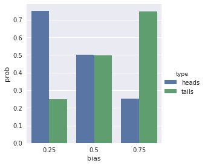

```python
result = []
N = 10000
for bias in [.25,.5,.75]:
    tosses = random_coin_toss(N, bias)
    num_heads = len([i for i in tosses if i])
    result.append({'prob':num_heads/N,
                   'type':'heads',
                   'bias':bias})
    result.append({'prob':1-num_heads/N,
                  'type':'tails',
                  'bias':bias})
sns.factorplot(x='bias',y='prob',hue='type',
               data=pd.DataFrame(result),
               kind='bar')
```

So now we can ask the question, given a coin which may or may not be biased can we tell if it is biased or not? Intuitively, if the coin is quite biased, this should be easier than if it is only slightly biased. Of course we will generate all the data ourselves, so we can check easily check the accuracy of our results.

So lets say we have flipped a coin $N$ times and computed the mean value of these flips. If $N$ is small, we expect that if we repeated these flips again $M$ times, we would have quite a large variation in our results, if $N$ is large, we expect it to be less so.

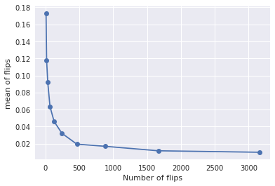

```python
n_list = np.logspace(1, 3.5, 10).astype(int)
std_list = []
for N in n_list:
    flip_means = np.zeros(100)
    for i in range(100):
        flip_means[i] = np.mean(random_coin_toss(N, .5))
    std_list.append(np.std(flip_means))
plt.plot(n_list, std_list,'o-')
plt.xlabel('Number of flips')
plt.ylabel('mean of flips')
```